# Homework

# The homework 9

##Anwers

11.3

```r
#a Write a function to compute
set.seed(1234)
f<-function(a,d,k){
  b<-(-1)^k/2^k/gamma(k+1)
  c<-(sum(a*a))^(2*k+2)/(2*k+1)/(2*k+2)
  e<-gamma((d+1)/2)*gamma(k+3/2)/gamma(k+d/2+1)
  s<-b*c*e
  return(s)
}
```

```r
#b Modify the function so that it computes and returns the sum
g<-function(n){
  s=0
  for (k in 0:n){
    s = s + f(a,d,k)
    return(s)
  }
}
```

```r
#c Evaluate the sum
a<-c(1,2)
d<-2
n<-1000
s<-g(n)
print(s)
```

```
## [1] 9.817477
```

11.5

```r
#First define the function to be called
rm(list=ls())
k=4
ck<-function(k,a){
  return(sqrt(a^2*k/(k+1-a^2)))
}
wf1 <- function(u) {
  (1+u*u/(k-1))^(-k/2)
}
wf2<- function(u) {
  (1+u*u/k)^(-(k+1)/2)
}
wf3<-function(a){
  2*gamma(k/2)/(sqrt(pi*(k-1))*gamma((k-1)/2))*integrate(wf1,0,ck(k-1,a))$value-2*gamma((k+1)/2)/(sqrt(pi*k)*gamma(k/2))*integrate(wf2,0,ck(k,a))$value
}
```

```r
#the root value of a under different values of k
kt<-c(seq(4,25,1),100,200)
solution11.5<-solution11.4<-numeric(length(kt))
js=1
for (i in kt) {
  k<-kt[js]
  solution11.5[js]<-uniroot(wf3,c(0.001,sqrt(k)/2+1))$root
  js=js+1
}
```

Calculate 11.4, the root value of a with different values of k

```r
#the root value of a with different values of k
js=1
wf4<-function(a){pt(sqrt(a^2*(k-1)/(k-a^2)),k-1)-pt(sqrt(a^2*k/(k+1-a^2)),k)}
for (i in kt) {
  k<-kt[js]
  solution11.4[js]<-uniroot(wf4,c(0.00001,sqrt(k)-0.0001))$root
  js=js+1
}
data.frame(kt,solution11.4,solution11.5)
```

```
##     kt solution11.4 solution11.5
## 1    4     1.492103     1.492103
## 2    5     1.533548     1.533567
## 3    6     1.562768     1.562719
## 4    7     1.584421     1.584429
## 5    8     1.601182     1.601183
## 6    9     1.614523     1.614522
## 7   10     1.625387     1.625383
## 8   11     1.634409     1.634409
## 9   12     1.642025     1.642019
## 10  13     1.648540     1.648540
## 11  14     1.654177     1.654194
## 12  15     1.659098     1.659120
## 13  16     1.663451     1.663408
## 14  17     1.667288     1.667273
## 15  18     1.670736     1.670724
## 16  19     1.673841     1.673817
## 17  20     1.676588     1.676607
## 18  21     1.679139     1.679154
## 19  22     1.681461     1.681479
## 20  23     4.795732     1.683578
## 21  24     4.898879     1.685521
## 22  25     4.999900     1.687347
## 23 100     9.999900     1.720600
## 24 200    14.142036     1.726318
```

$\textbf{Question3}$

1. The observed data MLE
   $$L(\lambda)=P(T>\tau)^{n-n_{0}} \cdot \lambda^{-n_{0}} e^{-\frac{1}{\lambda} \sum_{i=1}^{n_{0}} y_{i}}$$
   其中$n_{0}$为真实样本的个数，解得$\lambda$的MLE为
   $$\hat{\lambda}=\frac{\tau\left(n-n_{0}\right)+\sum_{i=1}^{n_{0}} y_{i}}{n_{0}}$$
   So we get the observed data，which $\tau=1, n=10, n_{0}=7$, and true observation data $0.54,0.48,0.33,0.43,0.91,0.21,0.85$.
2. Use the $E-M$ algorithe to evaluate $\lambda$.
   $$L(\lambda)=\lambda^{-n} e^{-\frac{1}{\lambda}} \sum_{i=1}^{n} t_{i}\\$$
   (1)E step:
   $$Q\left(\lambda, \lambda^{(i)}\right)=E\left[\ln L(\lambda) \mid Y, \lambda^{(i)}\right]\\
   =-n\ln \lambda-\frac{1}{\lambda} \sum_{i=1}^{n} y_{i}-\frac{\left(n-n_{0}\right) \lambda^{(t)}}{\lambda}$$
3. M step:maximization
   $$\begin{aligned}
   \frac{\partial Q\left(\lambda, \lambda^{(i)}\right)}{\partial \lambda}=&-\frac{n}{\lambda}+\frac{\sum_{i=1}^{n} y_{i}+\left(n-n_{0}\right) \lambda^{(0)}}{\lambda^{2}}=0 \\
   \lambda^{(i+1)} &=\frac{1}{n} \sum_{i=1}^{n} y_{i}+\frac{n-n_{0}}{n} \lambda^{[i]}\\
   \Rightarrow \bar{\lambda}=\frac{1}{n_{0}} \sum_{i=1}^{n} y_{i}
   \end{aligned}$$
   Compare the estimation of EM algorithe and the observed data MLE:
   $$\bar{\lambda}=\frac{1}{n_{0}} \sum_{i=1}^{n} y_{i} \\
   \hat{\lambda}=\frac{\tau\left(n-n_{0}\right)+\sum_{j=1}^{n_{0}} y_{i}}{n_{0}}$$

```r
#EM algorithe
set.seed(1234)
N<-100
lambda<-numeric(N)
n<-10;n0<-7
y<-c(0.54,0.48,0.33,0.43,1.0,1.0,0.91,1.0,0.21,0.85)
for(i in 1:N){
  lambda[1]<-0
  lambda[i+1]<-mean(y)+(n-n0)/n*lambda[i]   #迭代过程
  if(abs(lambda[i+1]-lambda[i])<1e-6) break  #设定误差为小于1e-6
  lambda_bar<-lambda[i+1]
}
```

```r
#MLE
set.seed(1234)
n<-10;n0<-7;tau<-1
y0<-c(0.54,0.48,0.33,0.43,0.91,0.21,0.85)
lambda_hat<-(tau*(n-n0)+sum(y0))/n0
round(c(lambda_bar,lambda_hat),7)
```

```
## [1] 0.9642852 0.9642857
```

结果发现EM算法和MLE结果十分接近

# The homework 10

##Answer

$\textbf{Question1:}$

Why are the following tow invocations of lappy() equivalent?
$$trims<-c(0,0.1,0.2,0.5)\\
x<-rcauchy(100)\\
lapply(trims,function(trims) mean(x,trim=trims))\\
lapply(trims,mean,x=x)$$
#他们的运行结果相同是因为一个先调用函数再带入数据使用lappy,另一个直接带入数据调用lappy函数，所以出来的结果是相同的。

$\textbf{Question2:}$

```r
# For the first model
formulas <- list(
  mpg ~ disp,
  mpg ~ I(1 / disp),
  mpg ~ disp + wt,
  mpg ~ I(1 / disp) + wt
)
wf <- numeric(4)
rsq <- function(mod) summary(mod)$r.squared
j = 1:4
wf <- lapply(j,function(j) {rsq(lm(formulas[[j]], data = mtcars))})
wf
```

```
## [[1]]
## [1] 0.7183433
##
## [[2]]
## [1] 0.8596865
##
## [[3]]
## [1] 0.7809306
##
## [[4]]
## [1] 0.8838038
```

```r
# For the second model
bootstraps <- lapply(1:10, function(i) {
  rows <- sample(1:nrow(mtcars), rep = TRUE)
  mtcars[rows, ]
})
wf <- numeric(10)
rsq <- function(mod) summary(mod)$r.squared
j = 1:10
wf <- lapply(j,function(j) {rsq(lm(formulas[[1]], data = bootstraps[[j]]))})
wf
```

```
## [[1]]
## [1] 0.7817567
##
## [[2]]
## [1] 0.7813869
##
## [[3]]
## [1] 0.7191574
##
## [[4]]
## [1] 0.7880896
##
## [[5]]
## [1] 0.6350857
##
## [[6]]
## [1] 0.8092306
##
## [[7]]
## [1] 0.7153903
##
## [[8]]
## [1] 0.7117518
##
## [[9]]
## [1] 0.6652465
##
## [[10]]
## [1] 0.5906548
```

$\textbf{Question3:}$

```r
#a
su<-function(x){
  funs<-c(sd)
  sapply(funs,function(f) f(x,na.rm=TRUE))
}
df<-data.frame(replicate(3,runif(10,1,10)))
round(vapply(df,su,FUN.VALUE = c(sd=0)),3)
```

```
##    X1    X2    X3
## 2.469 2.895 3.246
```

```r
#b
su<-function(x){
  funs<-c(sd)
  sapply(funs,function(f) f(x,na.rm=TRUE))
}
df<-data.frame(x<-replicate(3,runif(10,1,10)),c(list("A","B","C")))
round(vapply(df,su,FUN.VALUE = c(sd=0)),3)
```

```
##    X1    X2    X3  X.A.  X.B.  X.C.
## 2.578 2.740 2.556    NA    NA    NA
```

$\textbf{Question4:}$

```r
library(parallel)
formulas <- list(
  l1<-function(mtcars) glm(mtcars$mpg ~ mtcars$disp),l2<-function(mtcars) glm(mtcars$mpg ~ I(1 / mtcars$disp)),l3<-function(mtcars) glm(mtcars$mpg ~ mtcars$disp + mtcars$wt),l4<-function(mtcars) glm(mtcars$mpg ~ I(1 / mtcars$disp) +mtcars$wt)
)
cl<-makeCluster(4)
bootstraps2 <- lapply(1:3000, function(i) {
  rows <- sample(1:nrow(mtcars), rep = TRUE)
  mtcars[rows, ]})
system.time(sapply(bootstraps2,formulas[[1]]))
```

```
## 用户 系统 流逝
## 4.78 0.03 4.85
```

```r
system.time(parSapply(cl,bootstraps2,formulas[[1]]))
```

```
## 用户 系统 流逝
## 0.75 0.10 3.65
```

# The homework 11

##Anwerse

## Answer

```r
#生成R函数
R_Gibbs<-function(n,a,b){
  N <- 10000 #连的长度
  X <- matrix(0, N, 2) #定义一个二元变量
  X[1, ] <- c(1, 0.5) #初始值
  for (i in 2:N) {
    x2 <- X[i-1, 2]
    #生成二项分布的随机数
    X[i, 1] <- rbinom(1,n,x2)
    x1 <- X[i, 1]
    #生成贝塔分布的随机数
    X[i, 2] <- rbeta(1, x1+a, n-x1+b)
  }

  return(X)
}
```

```r
#生成Rcpp函数
library(Rcpp)
cppFunction('NumericMatrix C_Gibbs(int n,double a, double b){
            int N=10000;
            int x;
            double y;
            NumericMatrix M(N,2);
            M(0,0)=1;
            M(0,1)=0.5;
            for(int i=1;i<N;i++){
            y=M(i-1,1);
            M(i,0)=rbinom(1,n,y)[0];
            x=M(i,0);
            M(i,1)=rbeta(1,x+a,n-x+b)[0];
            }
            return(M) ;
            }')
```

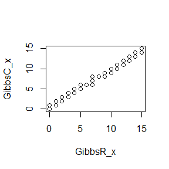

```r
set.seed(0)#设定随机种子
burn<-1000
N<-10000 #循环次数
GibbsR=R_Gibbs(15,3,3) #调用函数
GibbsR<-GibbsR[(burn+1):N,]
GibbsC=C_Gibbs(15,3,3)
GibbsC<-GibbsC[(burn+1):N,]
#分别抽取边际变量值
GibbsR_x<-GibbsR[,1]
GibbsR_y<-GibbsR[,2]

GibbsC_x<-GibbsC[,1]
GibbsC_y<-GibbsC[,2]
#画QQ图
qqplot(GibbsR_x,GibbsC_x)
```

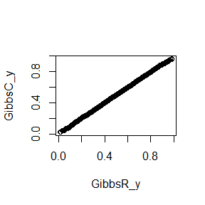

```r
qqplot(GibbsR_y,GibbsC_y)
```

```r
library(microbenchmark)
#比较计算速度
time<-microbenchmark(GibbsR=R_Gibbs(15,3,3),GibbsC=C_Gibbs(15,3,3))
summary(time)[, c(1,3,5,6)]
```

```
##     expr        lq    median        uq
## 1 GibbsR 63.504051 65.501102 83.309001
## 2 GibbsC  4.841951  5.048701  6.424901
```